# COVID-19 Analysis For INDIA and World

Ayushi Bansal

22/05/2020

## Predictions and Plots

So this little project is just for us to learn and apply the simple techniques used in statistical learning in a real time problem in the world.

Here we predict two things:

1. No. of confirmed cases for the next few days for the world.
2. No. of confirmed cases for the next few days for India.

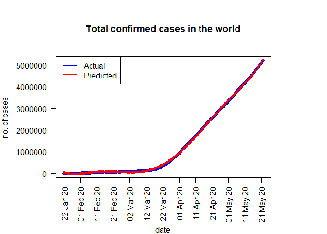

TABLE 1: This is the predictions for the world

| Date | Prediction Fit | Minimum | Maximum |
| --- | --- | --- | --- |
| 2020-05-22 | 5,257,890 | 5,223,314 | 5,292,467 |
| 2020-05-23 | 5,395,590 | 5,353,495 | 5,437,686 |
| 2020-05-24 | 5,543,586 | 5,492,524 | 5,594,647 |
| 2020-05-25 | 5,703,030 | 5,641,480 | 5,764,580 |
| 2020-05-26 | 5,875,155 | 5,801,500 | 5,948,811 |
| 2020-05-27 | 6,061,271 | 5,973,783 | 6,148,759 |
| 2020-05-28 | 6,262,771 | 6,159,599 | 6,365,943 |

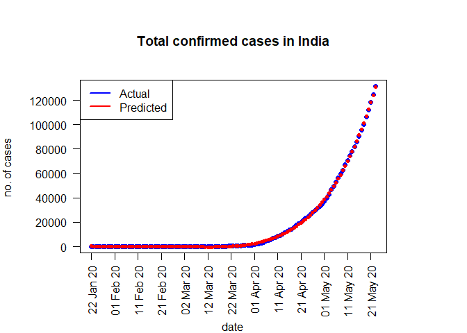

TABLE 2: This is the prediction for India

[output not shown]

## Explanation, Inference and Error Analysis

The polynomial used was of degree six as we used the method of cross validation to determine which degree will give lowest error and less computations. We concluded that degree 6 was fitting the model perfectly. However, other models were also considered for this job but none gave as much accuracy than this simple polynomial.

TABLE 3: This table represents the Average Percentage error of the prediction model of World

| Date | Prediction | Actual | Average Error % |
| --- | --- | --- | --- |
| 2020-05-10 | 4,271,809 | 4,261,747 | 0.236 |
| 2020-05-11 | 4,365,072 | 4,347,018 | 0.415 |
| 2020-05-12 | 4,458,989 | 4,442,163 | 0.379 |
| 2020-05-13 | 4,557,545 | 4,542,347 | 0.335 |
| 2020-05-14 | 4,661,680 | 4,634,068 | 0.596 |
| 2020-05-15 | 4,766,332 | 4,713,620 | 1.118 |
| 2020-05-16 | 4,866,016 | 4,801,943 | 1.334 |
| 2020-05-17 | 4,965,238 | 4,897,492 | 1.383 |
| 2020-05-18 | 5,066,875 | 4,996,472 | 1.409 |
| 2020-05-19 | 5,171,589 | 5,102,424 | 1.356 |
| 2020-05-20 | 5,281,290 | 5,210,817 | 1.352 |

TABLE 4: This table represents the Average Percentage error of the prediction model of India

| Date | Prediction | Actual | Average Error % |
| --- | --- | --- | --- |
| 2020-05-10 | 74,712 | 74,292 | 0.566 |
| 2020-05-11 | 78,873 | 78,055 | 1.049 |
| 2020-05-12 | 83,033 | 81,997 | 1.264 |
| 2020-05-13 | 87,241 | 85,784 | 1.698 |
| 2020-05-14 | 91,391 | 90,648 | 0.82 |
| 2020-05-15 | 95,927 | 95,698 | 0.239 |
| 2020-05-16 | 100,815 | 100,328 | 0.485 |
| 2020-05-17 | 105,773 | 106,475 | 0.659 |
| 2020-05-18 | 111,381 | 112,028 | 0.577 |
| 2020-05-19 | 117,222 | 118,226 | 0.849 |
| 2020-05-20 | 123,469 | 124,794 | 1.061 |